# eda_model_build

```python
import sys
sys.path.insert(1, '../industrial_tsp/industrial_tsp')
import config as config
import custom_funcs as funcs

import pandas as pd
import numpy as np
import matplotlib.pyplot as plt
import seaborn as sns
from statsmodels.tsa.stattools import adfuller, acf, pacf,arma_order_select_ic, ccf
from sklearn.model_selection import train_test_split
from statsmodels.tsa.arima_model import ARIMA
import statsmodels.api as sm
from sklearn.model_selection import GridSearchCV
from sklearn.ensemble import RandomForestRegressor
from sklearn.datasets import make_regression
import warnings
warnings.filterwarnings("ignore")
from sklearn.metrics import mean_squared_error
from sklearn.metrics import r2_score
import pickle

# We'll be using the Tensorflow backend (default).
from tensorflow.keras import Sequential
from tensorflow.keras.layers import Conv2D, Flatten, Dense, LSTM, Dropout, Activation
#from keras.layers.recurrent import LSTM
#from keras.layers.core import Dense, Activation, Dropout
from sklearn.preprocessing import MinMaxScaler, StandardScaler
from sklearn.metrics import mean_squared_error
from sklearn.utils import shuffle

from sklearn.model_selection import KFold

import keras_tuner as kt
from keras.optimizers import adam
from keras.losses import SparseCategoricalCrossentropy
from keras.callbacks import EarlyStopping
```

```python
raw_data_path = config.raw_data_path
sheet_name = config.sheet_name

df = pd.read_excel(raw_data_path, sheet_name=sheet_name)
df.columns=['timestamp', 'target', 'input_1','input_2','input_3','input_4','input_5','input_6']
df
```

|  | timestamp | target | input_1 | input_2 | input_3 | input_4 | input_5 | input_6 |
| --- | --- | --- | --- | --- | --- | --- | --- | --- |
| 0 | 2020-06-01 01:00:00.000 | 77.301848 | 7956.306758 | 4.504717 | 11.588595 | 106.005488 | 12.806226 | 55.120697 |
| 1 | 2020-06-01 00:00:00.000 | 82.529204 | 7984.083042 | 4.728041 | 11.135346 | 96.851560 | 12.341256 | 51.107401 |
| 2 | 2020-05-31 23:00:00.005 | 73.480763 | 7882.220342 | 4.510107 | 13.924257 | 91.861623 | 13.799334 | 61.504061 |
| 3 | 2020-05-31 22:00:00.010 | 81.624423 | 8194.176721 | 4.261714 | 8.707002 | 99.127532 | 15.506747 | 49.456463 |
| 4 | 2020-05-31 21:00:00.015 | 77.677522 | 8353.724133 | 4.439229 | 13.598622 | 99.231788 | 15.757422 | 42.845931 |
| ... | ... | ... | ... | ... | ... | ... | ... | ... |
| 2012 | 2020-03-09 05:00:10.055 | 111.689597 | 7934.819299 | 3.559798 | 8.141287 | 106.664267 | 9.372391 | 55.156266 |
| 2013 | 2020-03-09 04:00:10.060 | 111.338741 | 7949.980237 | 3.404680 | 10.017730 | 102.096123 | 10.467785 | 59.021275 |
| 2014 | 2020-03-09 03:00:10.065 | 109.859030 | 7777.036084 | 3.283431 | 9.630355 | 96.016541 | 13.880323 | 43.492279 |
| 2015 | 2020-03-09 02:00:10.070 | 118.163594 | 8238.361164 | 3.159954 | 9.203794 | 100.344544 | 13.949981 | 44.035358 |
| 2016 | 2020-03-09 01:00:10.075 | 109.377219 | 7688.721675 | 3.020244 | 8.041120 | 96.689396 | 13.047083 | 53.780062 |

2017 rows × 8 columns

It'd better to reverse the data to chronological order

```python
df=df.sort_values('timestamp', ascending=True)
df
```

|  | timestamp | target | input_1 | input_2 | input_3 | input_4 | input_5 | input_6 |
| --- | --- | --- | --- | --- | --- | --- | --- | --- |
| 2016 | 2020-03-09 01:00:10.075 | 109.377219 | 7688.721675 | 3.020244 | 8.041120 | 96.689396 | 13.047083 | 53.780062 |
| 2015 | 2020-03-09 02:00:10.070 | 118.163594 | 8238.361164 | 3.159954 | 9.203794 | 100.344544 | 13.949981 | 44.035358 |
| 2014 | 2020-03-09 03:00:10.065 | 109.859030 | 7777.036084 | 3.283431 | 9.630355 | 96.016541 | 13.880323 | 43.492279 |
| 2013 | 2020-03-09 04:00:10.060 | 111.338741 | 7949.980237 | 3.404680 | 10.017730 | 102.096123 | 10.467785 | 59.021275 |
| 2012 | 2020-03-09 05:00:10.055 | 111.689597 | 7934.819299 | 3.559798 | 8.141287 | 106.664267 | 9.372391 | 55.156266 |
| ... | ... | ... | ... | ... | ... | ... | ... | ... |
| 4 | 2020-05-31 21:00:00.015 | 77.677522 | 8353.724133 | 4.439229 | 13.598622 | 99.231788 | 15.757422 | 42.845931 |
| 3 | 2020-05-31 22:00:00.010 | 81.624423 | 8194.176721 | 4.261714 | 8.707002 | 99.127532 | 15.506747 | 49.456463 |
| 2 | 2020-05-31 23:00:00.005 | 73.480763 | 7882.220342 | 4.510107 | 13.924257 | 91.861623 | 13.799334 | 61.504061 |
| 1 | 2020-06-01 00:00:00.000 | 82.529204 | 7984.083042 | 4.728041 | 11.135346 | 96.851560 | 12.341256 | 51.107401 |
| 0 | 2020-06-01 01:00:00.000 | 77.301848 | 7956.306758 | 4.504717 | 11.588595 | 106.005488 | 12.806226 | 55.120697 |

2017 rows × 8 columns

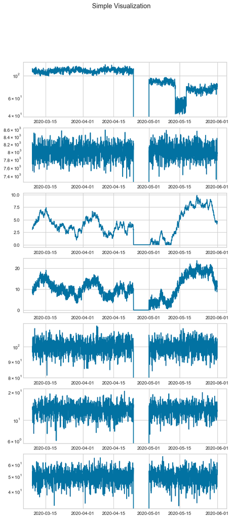

```python
fig, axs = plt.subplots(7, figsize=(8,18))
fig.suptitle('Simple Visualization')
numeric_cols=['target','input_1','input_2','input_3','input_4','input_5','input_6']
for i in range(len(numeric_cols)):
    #axs[i] = df[numeric_cols[i]].plot(figsize=(16,8))
    axs[i].plot(df['timestamp'], df.sort_values('timestamp', ascending=True)[numeric_cols[i]])
    if numeric_cols[i] in ['target','input_1','input_4','input_5','input_6']:
        axs[i].set_yscale('log')

# ax1 = df['Input_1'].plot(figsize=(16,8))
# ax1.set_yscale('log')
```

Things to note at the first glance:

It is obvious that there's a reset period. However are there any input sensors which has zero values, apart from that period?

```python
for col in numeric_cols:
    print(col ,df[(df[col] == 0) & (df['target'] > 0)][col].count())
```

```
target 0
input_1 0
input_2 49
input_3 0
input_4 0
input_5 0
input_6 0
```

Only Input_2 has this problem for 49 measurements. May there be a certain reason for that? Or are the readings actually 0?

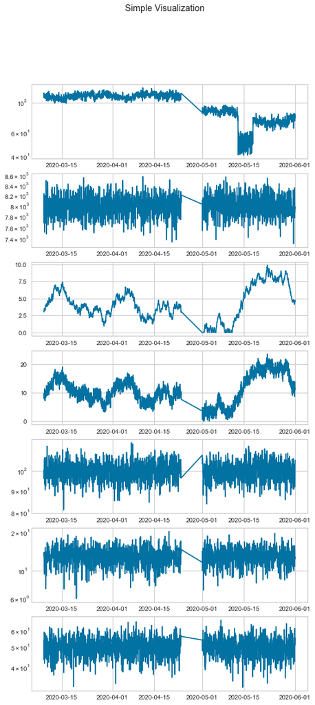

```python
df_non_reset = df[df['target']>0]
fig, axs = plt.subplots(7, figsize=(8,18))
fig.suptitle('Simple Visualization')
numeric_cols=['target','input_1','input_2','input_3','input_4','input_5','input_6']
for i in range(len(numeric_cols)):
    #axs[i] = df[numeric_cols[i]].plot(figsize=(16,8))
    axs[i].plot(df_non_reset['timestamp'], df_non_reset.sort_values('timestamp', ascending=True)[numeric_cols[i]])
    if numeric_cols[i] in ['target','input_1','input_4','input_5','input_6']:
        axs[i].set_yscale('log')
```

### Zero values for input 2

The strong visual correlation of Input 2 and 3 should be investigated:

- Input 2 values are 0 for some small periods due to some breakdown in the corresponding equipment. Due to correlation, Input 3 has also very low values

or

- The equipment/sensor that generates Input 2 and 3 perform normally, however as the value for any of them is reduced under a certain threshold, the sensor just produces zero

Here we need to learn the reason for this situation.

### Lag between Input 2 and 3

Another Key point is that, although Input 2 and 3 are moving paralelly, is there a lag between them? For this purpose I'm using cross correlation function

```python
cc_2_3 = ccf(df_non_reset['input_2'], df_non_reset['input_3'], adjusted=True)
cc_3_2 = ccf(df_non_reset['input_2'], df_non_reset['input_3'], adjusted=True)
```

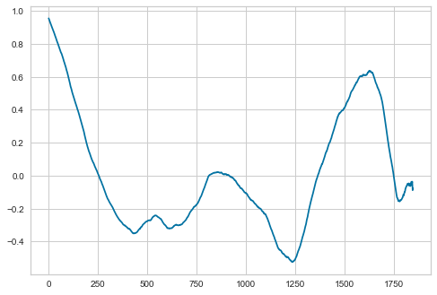

```python
plt.plot(cc_2_3)
```

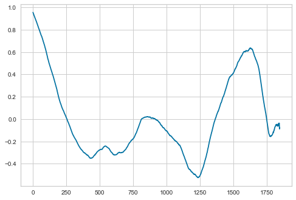

```python
plt.plot(cc_3_2)
```

Since we have max correlation at lag:0, I will assume that these 2 series, from Input 2 and 3 seem to be synchronized

### Reset Period

Returning back to the period in which all the inputs are 0 along with our target variable. Since we are dealing with time series data, the zero values cannot be omitted due to the continuity in our timestamps.

Since the gap is quite high, it's meaningful to impute that data according to timestamp characteristics. I need to visualize hourly, daily, weekly movements in the data

### The Reset Period - 1

Normally, I would really love to imputate the values that are 0, because it is really a sign of one or two things:

- A temporary maintenance: data could be refetched from archive
- Any type of incenvenience: imputate the data

However in our case, we assume that everything's fine, all readings are accurate etc. In that case these 0 values in the reset period is part of our dataset and should be included in our final prediction model. On the other hand, prior to our predictive model, we need to investigate characteristics of our dataset. That's why I'll make this inspection with a interpolated version of the set.

```python
df[numeric_cols[i]].replace(0, None).interpolate(method='polynomial', order=3)
```

```
2016    53.780062
2015    44.035358
2014    43.492279
2013    59.021275
2012    55.156266
          ...
4       42.845931
3       49.456463
2       61.504061
1       51.107401
0       55.120697
Name: input_6, Length: 2017, dtype: float64
```

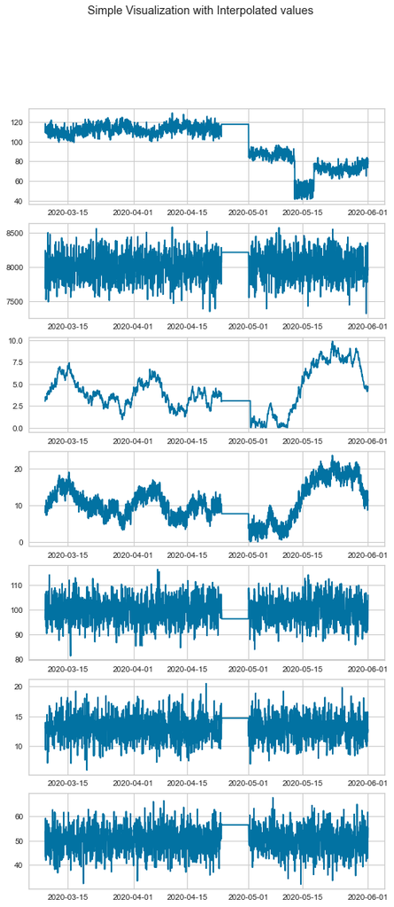

```python
fig, axs = plt.subplots(7, figsize=(8,18))
fig.suptitle('Simple Visualization with Interpolated values')
numeric_cols=['target','input_1','input_2','input_3','input_4','input_5','input_6']
for i in range(len(numeric_cols)):
    axs[i].plot(df['timestamp'], df[numeric_cols[i]].replace(0, None).interpolate(method='polynomial', order=3))
```

```python
df_interpolated = df.replace(0, None).interpolate(method='polynomial', order=3)
```

## Distributions

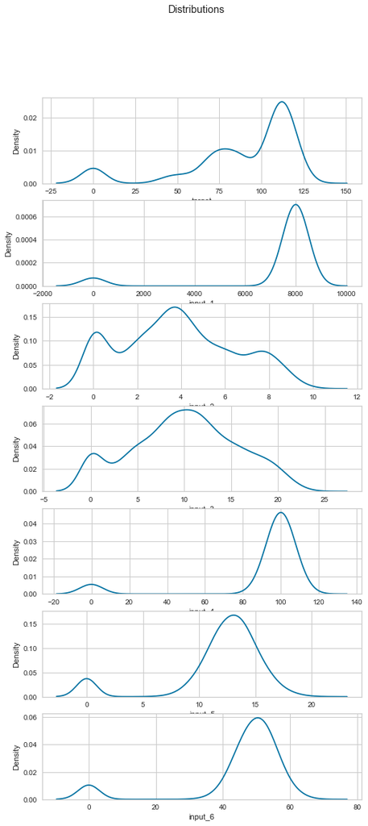

```python
fig, axs = plt.subplots(7, figsize=(8,18))
fig.suptitle('Distributions')
numeric_cols=['target','input_1','input_2','input_3','input_4','input_5','input_6']
for i in range(len(numeric_cols)):
    axs[i] = sns.kdeplot(data=df, x=numeric_cols[i], ax=axs[i])
```

The reset period causes some distortion in distributions

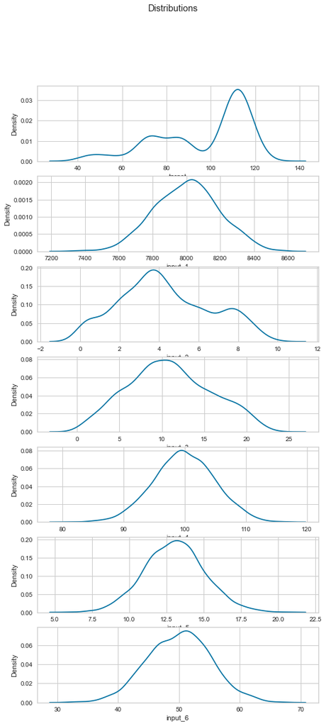

```python
fig, axs = plt.subplots(7, figsize=(8,18))
fig.suptitle('Distributions')
numeric_cols=['target','input_1','input_2','input_3','input_4','input_5','input_6']
for i in range(len(numeric_cols)):
    axs[i] = sns.kdeplot(data=df[df[numeric_cols[i]]>0], x=numeric_cols[i], ax=axs[i])
```

If we check the density of non-zero measurements, our inputs seem to be close to gaussian distribution. However that's not the case for our target variable. Let's check the temporal properties of the two peaks.

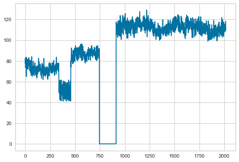

```python
df['target'].plot()
```

As seen in the above chart, the 2 peaks come from the separate distributions before and after the "reset"

To interpret this, we should know the ordinary values of our target variable.

```python
df['date'] = df['timestamp'].dt.date
df.head(1)
```

|  | timestamp | target | input_1 | input_2 | input_3 | input_4 | input_5 | input_6 | date |
| --- | --- | --- | --- | --- | --- | --- | --- | --- | --- |
| 2016 | 2020-03-09 01:00:10.075 | 109.377219 | 7688.721675 | 3.020244 | 8.04112 | 96.689396 | 13.047083 | 53.780062 | 2020-03-09 |

### Milliseconds Shift

This is one of the interesting things about our data, the time difference between our measurements are exactly 0 days 00:59:59.995 milliseconds.

- Is it a glitch in the sensor?
- There are readings in every 5 milliseconds, but only these ones are sampled
- Readings are sent 5 ms earlier before the exact hour, so the network delay will not overflow to the next hour.

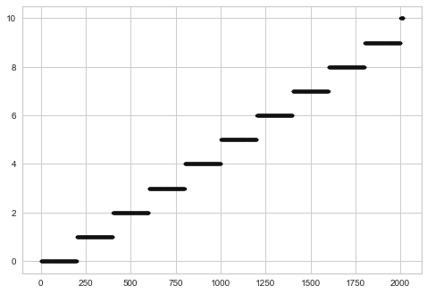

```python
df['seconds'] = df['timestamp'].dt.second
df.seconds.plot(style='.k')
```

```python
(df['timestamp'].shift(periods=1)-df['timestamp'])
```

```
2016                        NaT
2015   -1 days +23:00:00.005000
2014   -1 days +23:00:00.005000
2013   -1 days +23:00:00.005000
2012   -1 days +23:00:00.005000
                 ...
4      -1 days +23:00:00.005000
3      -1 days +23:00:00.005000
2      -1 days +23:00:00.005000
1      -1 days +23:00:00.005000
0             -1 days +23:00:00
Name: timestamp, Length: 2017, dtype: timedelta64[ns]
```

- Why's the gap between each reading is 5 milliseconds shorther than an hour?

## Temporal characteristics

Here I'm expecting to see the temporal characteristics of the data, prior to it's seasonality, stationarity and existance of a trend. This characteristics will be more useful while building our predictive model later, but it's still important to get to know it better.

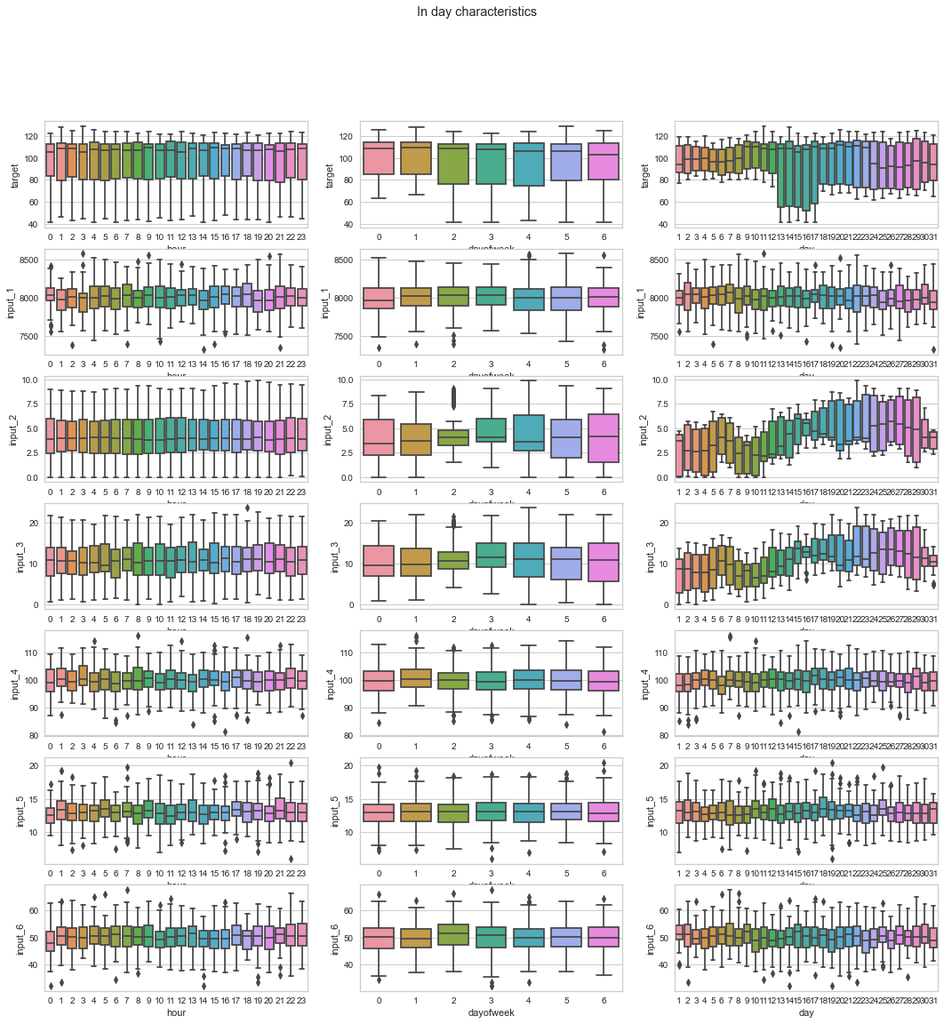

```python
df_non_reset['hour'] = df_non_reset['timestamp'].dt.hour
df_non_reset['dayofweek'] = df_non_reset['timestamp'].dt.dayofweek
df_non_reset['day'] = df_non_reset['timestamp'].dt.day

fig, axs = plt.subplots(7,3, figsize=(18,18))
fig.suptitle('In day characteristics')
for i in range(len(numeric_cols)):
    data_hourly = df_non_reset.groupby('hour')[numeric_cols[i]].mean().reset_index()
    data_week_day = df_non_reset.groupby('dayofweek')[numeric_cols[i]].mean().reset_index()
    data_month_date = df_non_reset.groupby('day')[numeric_cols[i]].mean().reset_index()

#     axs[i,0].boxplot(data_hourly.hour, data_hourly[numeric_cols[i]])
#     axs[i,1].boxplot(data_week_day.dayofweek, data_week_day[numeric_cols[i]])
#     axs[i,2].boxplot(data_month_date.day, data_month_date[numeric_cols[i]])
    sns.boxplot(data=df_non_reset, x='hour', y=numeric_cols[i], ax=axs[i,0])
    sns.boxplot(data=df_non_reset, x='dayofweek', y=numeric_cols[i], ax=axs[i,1])
    sns.boxplot(data=df_non_reset, x='day', y=numeric_cols[i], ax=axs[i,2])
```

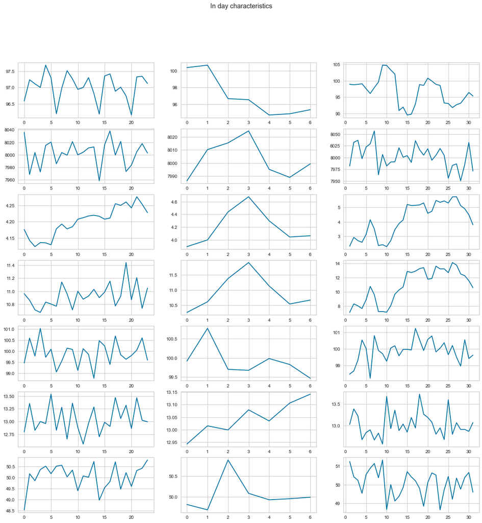

```python
df_non_reset['hour'] = df_non_reset['timestamp'].dt.hour
df_non_reset['dayofweek'] = df_non_reset['timestamp'].dt.dayofweek
df_non_reset['day'] = df_non_reset['timestamp'].dt.day

fig, axs = plt.subplots(7,3, figsize=(18,18))
fig.suptitle('In day characteristics')
for i in range(len(numeric_cols)):
    data_hourly = df_non_reset.groupby('hour')[numeric_cols[i]].mean().reset_index()
    data_week_day = df_non_reset.groupby('dayofweek')[numeric_cols[i]].mean().reset_index()
    data_month_date = df_non_reset.groupby('day')[numeric_cols[i]].mean().reset_index()

    axs[i,0].plot(data_hourly.hour, data_hourly[numeric_cols[i]])
    axs[i,1].plot(data_week_day.dayofweek, data_week_day[numeric_cols[i]])
    axs[i,2].plot(data_month_date.day, data_month_date[numeric_cols[i]])
```

The main takeaways here are:

```python
df_interpolated
```

|  | timestamp | target | input_1 | input_2 | input_3 | input_4 | input_5 | input_6 |
| --- | --- | --- | --- | --- | --- | --- | --- | --- |
| 2016 | 2020-03-09 01:00:10.075 | 109.377219 | 7688.721675 | 3.020244 | 8.041120 | 96.689396 | 13.047083 | 53.780062 |
| 2015 | 2020-03-09 02:00:10.070 | 118.163594 | 8238.361164 | 3.159954 | 9.203794 | 100.344544 | 13.949981 | 44.035358 |
| 2014 | 2020-03-09 03:00:10.065 | 109.859030 | 7777.036084 | 3.283431 | 9.630355 | 96.016541 | 13.880323 | 43.492279 |
| 2013 | 2020-03-09 04:00:10.060 | 111.338741 | 7949.980237 | 3.404680 | 10.017730 | 102.096123 | 10.467785 | 59.021275 |
| 2012 | 2020-03-09 05:00:10.055 | 111.689597 | 7934.819299 | 3.559798 | 8.141287 | 106.664267 | 9.372391 | 55.156266 |
| ... | ... | ... | ... | ... | ... | ... | ... | ... |
| 4 | 2020-05-31 21:00:00.015 | 77.677522 | 8353.724133 | 4.439229 | 13.598622 | 99.231788 | 15.757422 | 42.845931 |
| 3 | 2020-05-31 22:00:00.010 | 81.624423 | 8194.176721 | 4.261714 | 8.707002 | 99.127532 | 15.506747 | 49.456463 |
| 2 | 2020-05-31 23:00:00.005 | 73.480763 | 7882.220342 | 4.510107 | 13.924257 | 91.861623 | 13.799334 | 61.504061 |
| 1 | 2020-06-01 00:00:00.000 | 82.529204 | 7984.083042 | 4.728041 | 11.135346 | 96.851560 | 12.341256 | 51.107401 |
| 0 | 2020-06-01 01:00:00.000 | 77.301848 | 7956.306758 | 4.504717 | 11.588595 | 106.005488 | 12.806226 | 55.120697 |

2017 rows × 8 columns

```python
numeric_cols
```

```
['target', 'input_1', 'input_2', 'input_3', 'input_4', 'input_5', 'input_6']
```

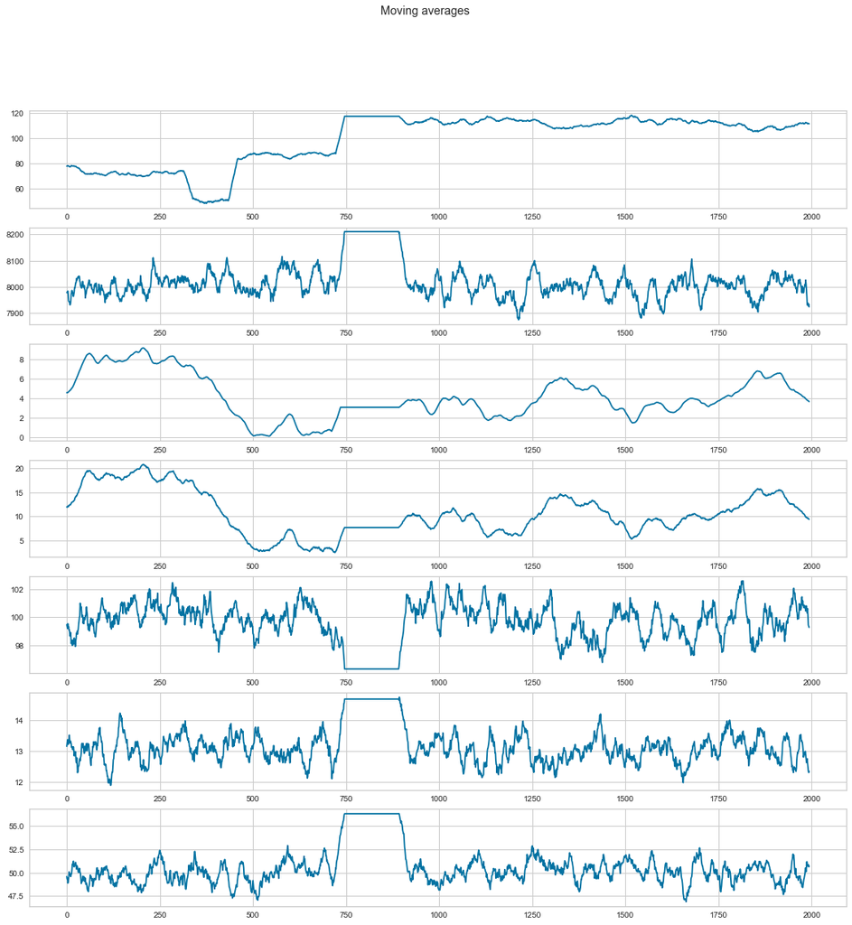

```python
#let's check seasonality with ma
for col in numeric_cols:
    ma_col_name = col+'ma(50)'
    df_interpolated[ma_col_name] = df_interpolated[col].rolling(window=24).mean()


fig, axs = plt.subplots(7, figsize=(18,18))
fig.suptitle('Moving averages')
for i in range(len(numeric_cols)):
    col = numeric_cols[i]+'ma(50)'
    axs[i].plot(df_interpolated[df_interpolated[numeric_cols[i]]>0][col])
#     if numeric_cols[i] in ['target','input_1','input_4','input_5','input_6']:
#         axs[i].set_yscale('log')
```

## Seasonal Decomposition

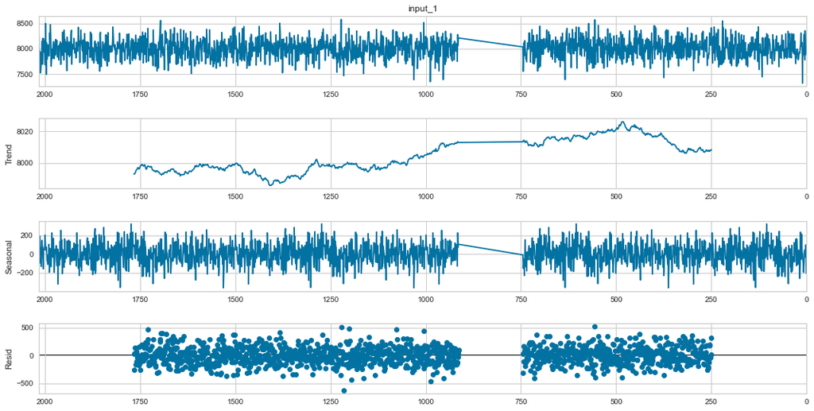

```python
import statsmodels.api as sm
# multiplicative
res = sm.tsa.seasonal_decompose(df[df['input_1']>0]['input_1'],freq=500,model="additive")

fig = res.plot()
fig.set_figheight(8)
fig.set_figwidth(16)
```

### Stationarity

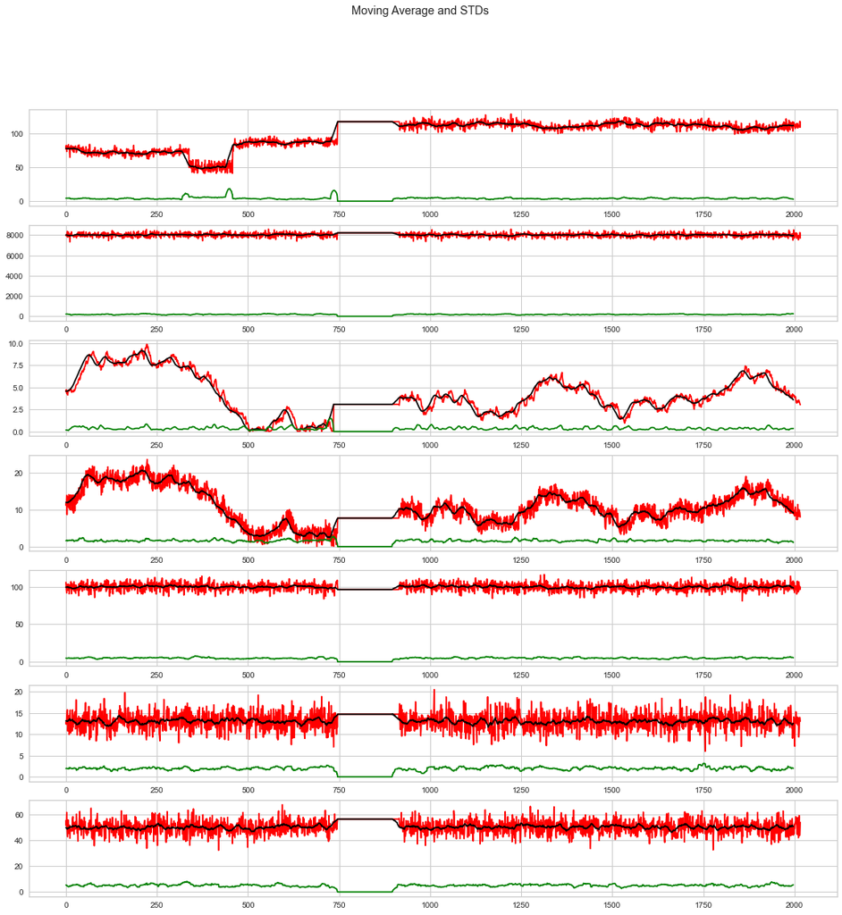

```python
def check_mean_std(data):
    fig, axs = plt.subplots(7, figsize=(18, 18))
    fig.suptitle('Moving Average and STDs')
    for i in range(len(numeric_cols)):
        timeseries = data[numeric_cols[i]]
        rolmean = timeseries.rolling(window=20).mean()
        rolstd = timeseries.rolling(window=20).std()

        orig = axs[i].plot(timeseries, color='red', label='Original')
        mean = axs[i].plot(rolmean, color='black', label='Rolling Mean')
        std = axs[i].plot(rolstd, color='green', label='Rolling Std')

check_mean_std(df_interpolated)
```

As we visually check the constant means and constant STDs,

To investigate further, I'll apply augmented dickey fuller test

```python
funcs.check_stationarity(df_interpolated['target'], 'target')
funcs.check_stationarity(df_interpolated['input_1'], 'input_1')
funcs.check_stationarity(df_interpolated['input_2'], 'input_2')
funcs.check_stationarity(df_interpolated['input_3'], 'input_3')
funcs.check_stationarity(df_interpolated['input_4'], 'input_4')
funcs.check_stationarity(df_interpolated['input_5'], 'input_5')
funcs.check_stationarity(df_interpolated['input_6'], 'input_6')
```

```
Results of Dickey-Fuller Test for target:
Test Statistic                   -1.443021
p-value                           0.561487
#Lags Used                        6.000000
Number of Observations Used    2010.000000
Critical Value (1%)              -3.433608
Critical Value (5%)              -2.862979
Critical Value (10%)             -2.567536
dtype: float64
Results of Dickey-Fuller Test for input_1:
Test Statistic                -5.809185e+00
p-value                        4.442582e-07
#Lags Used                     2.000000e+01
Number of Observations Used    1.996000e+03
Critical Value (1%)           -3.433630e+00
Critical Value (5%)           -2.862989e+00
Critical Value (10%)          -2.567541e+00
dtype: float64
Results of Dickey-Fuller Test for input_2:
Test Statistic                   -1.994734
p-value                           0.288887
#Lags Used                        0.000000
Number of Observations Used    2016.000000
Critical Value (1%)              -3.433598
Critical Value (5%)              -2.862975
Critical Value (10%)             -2.567534
dtype: float64
Results of Dickey-Fuller Test for input_3:
Test Statistic                   -2.297951
p-value                           0.172630
#Lags Used                        7.000000
Number of Observations Used    2009.000000
Critical Value (1%)              -3.433609
Critical Value (5%)              -2.862980
Critical Value (10%)             -2.567536
dtype: float64
Results of Dickey-Fuller Test for input_4:
Test Statistic                -8.018351e+00
p-value                        2.108939e-12
#Lags Used                     1.500000e+01
```

[output cut: 8 more lines]

```
#Lags Used                     1.300000e+01
Number of Observations Used    2.003000e+03
Critical Value (1%)           -3.433619e+00
Critical Value (5%)           -2.862984e+00
Critical Value (10%)          -2.567539e+00
dtype: float64
Results of Dickey-Fuller Test for input_6:
Test Statistic                   -5.508679
p-value                           0.000002
#Lags Used                       21.000000
Number of Observations Used    1995.000000
Critical Value (1%)              -3.433632
Critical Value (5%)              -2.862990
Critical Value (10%)             -2.567542
dtype: float64
```

Now, Augmented Dickey Fuller test is also supporting our visual inspections for constant mean and std's. According to our p values, and comparison of test statistic vs critical values, target, input_2 and input_3 variables do not have stationarity, while inputs 1,4,5,6 have stationarity.

## Resolving Nonstationairty

### Detrending & Differencing

```
Results of Dickey-Fuller Test for target:
Test Statistic                -1.034692e+01
p-value                        2.596543e-18
#Lags Used                     6.000000e+00
Number of Observations Used    1.991000e+03
Critical Value (1%)           -3.433639e+00
Critical Value (5%)           -2.862993e+00
Critical Value (10%)          -2.567543e+00
dtype: float64
Results of Dickey-Fuller Test for input_2:
Test Statistic                -7.774362e+00
p-value                        8.749211e-12
#Lags Used                     2.200000e+01
Number of Observations Used    1.975000e+03
Critical Value (1%)           -3.433665e+00
Critical Value (5%)           -2.863005e+00
Critical Value (10%)          -2.567550e+00
dtype: float64
Results of Dickey-Fuller Test for input_3:
Test Statistic                -1.169041e+01
p-value                        1.658005e-21
#Lags Used                     5.000000e+00
Number of Observations Used    1.992000e+03
Critical Value (1%)           -3.433637e+00
Critical Value (5%)           -2.862992e+00
Critical Value (10%)          -2.567543e+00
dtype: float64
```

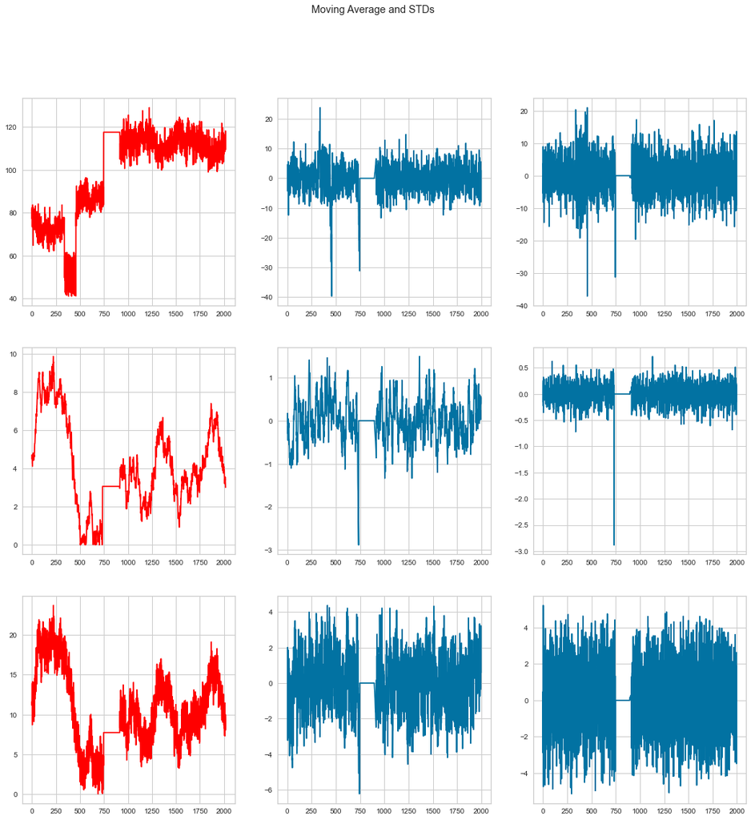

```python
non_stationary_cols = ['target', 'input_2', 'input_3']

fig, axs = plt.subplots(3,3, figsize=(18,18))
fig.suptitle('Moving Average and STDs')
for i in range(len(non_stationary_cols)):
    col=non_stationary_cols[i]

    #detrending
    ts = df_interpolated[col]
    window_size = 20
    moving_avg = ts.rolling(window=window_size).mean()

    #
    ts_moving_avg_diff = ts - moving_avg
    ts_moving_avg_diff.dropna(inplace=True)

    ts_diff = ts_moving_avg_diff - ts_moving_avg_diff.shift()

    axs[i,0].plot(ts, color='red',label='Original')
    axs[i,1].plot(ts_moving_avg_diff, label='Detrended')
    axs[i,2].plot(ts_diff, label='Differenced')

    funcs.check_stationarity(ts_moving_avg_diff, col)
```

As a result of the detrending & deseasoning, with the support p-values to the visual results, our inputs 2 and 3 became stationary along with the target.

## Data Correlation Investigation

In this section we need to investigate the dependency of our inputs among each other and with the target in terms of, causality and cointegration.

#### Cointegration

Here I'll check for the Johansen cointegration test results, if the resulting eigenvalue modulos are smaller than 1. Normally this is necessity for vector autocorrelation models, yet I need to make sure if I can use all of the inputs.

```python
#checking stationarity
from statsmodels.tsa.vector_ar.vecm import coint_johansen
#since the test works for only 12 variables, I have randomly dropped
#in the next iteration, I would drop another and check the eigenvalues
johan_test_temp = df_interpolated[numeric_cols]
res = coint_johansen(johan_test_temp,-1,1)
res.eig
```

```
array([3.50426037e-01, 3.21272765e-01, 2.97535516e-01, 2.17047135e-01,
       6.16664472e-03, 2.47132589e-03, 4.22604557e-05])
```

All of the eigenvalue modulos are smaller than 1

#### Causality

I have already performed a cross correlation test for inputs 2 and 3, I want to see a better picture of all the variables.

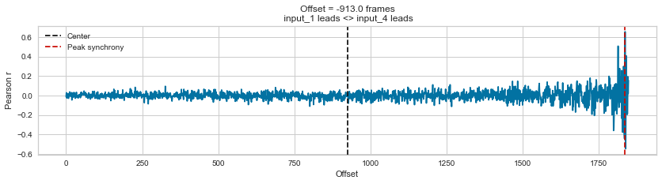

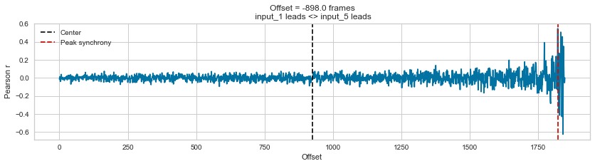

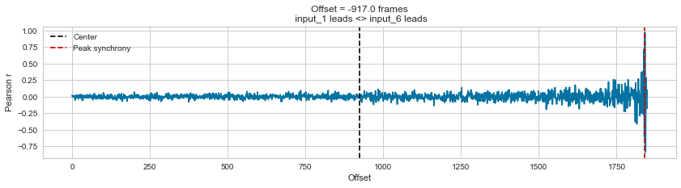

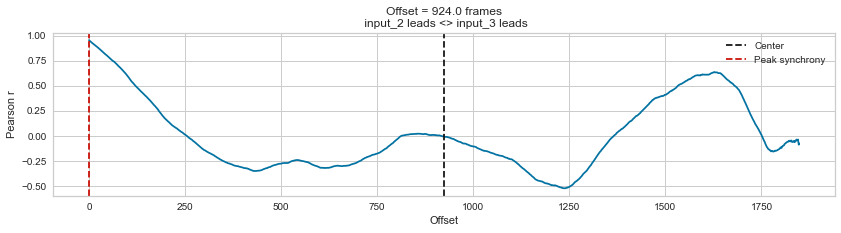

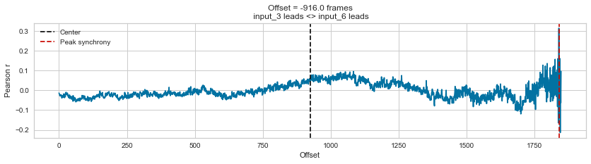

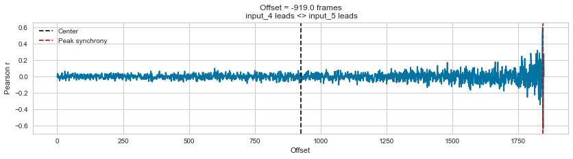

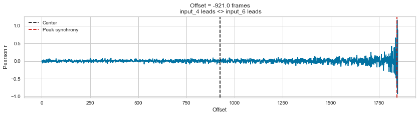

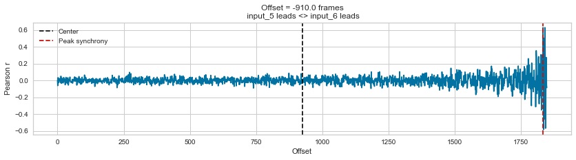

```python
input_cols = ['input_1','input_2','input_3','input_4','input_5','input_6']
for i in range(len(input_cols)):
    for j in range(i+1, len(input_cols)):
        ccres = ccf(df_non_reset[input_cols[i]], df_non_reset[input_cols[j]], adjusted=True)
        if ccres.max()>0.3:
            rs=ccres
            offset = np.floor(len(rs)/2)-np.argmax(rs)
            f,ax=plt.subplots(figsize=(14,3))
            ax.plot(rs)
            ax.axvline(np.ceil(len(rs)/2),color='k',linestyle='--',label='Center')
            ax.axvline(np.argmax(rs),color='r',linestyle='--',label='Peak synchrony')
            ax.set(title='Offset = {} frames\n {} leads <> {} leads'.format(offset, input_cols[i], input_cols[j]), xlabel='Offset',ylabel='Pearson r')

            plt.legend()
```

According to result of our lagged cross correlations, we have figured out that, the synch between high correlation inputs are really low. So it's safe to say the causality is minimal in this set

## Preprocessing the Data

As proposed above, Inputs 2 and 3 should be made stationary prior to the prediction phase

```python
df_pred = df_interpolated.copy()
df_pred=df_pred[['timestamp', 'target', 'input_1', 'input_2', 'input_3', 'input_4', 'input_5', 'input_6']]
df_pred['input_2'] = funcs.detrend(df_pred['input_2'])
df_pred['input_2'] = funcs.difference(df_pred['input_2'])
df_pred['input_3'] = funcs.detrend(df_pred['input_4'])
df_pred['input_3'] = funcs.difference(df_pred['input_4'])
```

```python
prediction_horizon = 6
vector_length = 6

df_pred = funcs.set_vector_date(df_pred, vector_length)
df_pred = funcs.set_target_in_ph(df_pred, prediction_horizon)
df_pred = funcs.set_target_in_ph(df_pred, 9)
df_pred = funcs.set_target_in_ph(df_pred, 12)
df_pred.dropna(inplace=True)
df_pred.head()
```

|  | timestamp | target | input_1 | input_2 | input_3 | input_4 | input_5 | input_6 | target_t-1 | target_t-2 | ... | input_5_t-6 | input_6_t-1 | input_6_t-2 | input_6_t-3 | input_6_t-4 | input_6_t-5 | input_6_t-6 | target_in_oh_6 | target_in_oh_9 | target_in_oh_12 |
| --- | --- | --- | --- | --- | --- | --- | --- | --- | --- | --- | --- | --- | --- | --- | --- | --- | --- | --- | --- | --- | --- |
| 1990 | 2020-03-10 03:00:09.945 | 113.890589 | 8038.413776 | 0.087164 | 9.513506 | 111.833491 | 16.789298 | 43.482108 | 115.779947 | 113.556281 | ... | 12.068524 | 49.866406 | 51.533369 | 44.105365 | 56.711925 | 50.812171 | 50.064997 | 112.802495 | 104.506708 | 117.721545 |
| 1989 | 2020-03-10 04:00:09.940 | 116.525672 | 7851.747411 | -0.175873 | 2.458084 | 114.291575 | 13.501749 | 55.335668 | 113.890589 | 115.779947 | ... | 9.077386 | 43.482108 | 49.866406 | 51.533369 | 44.105365 | 56.711925 | 50.812171 | 102.894975 | 114.097145 | 121.784510 |
| 1988 | 2020-03-10 05:00:09.935 | 105.511864 | 7862.169307 | -0.030283 | -15.122110 | 99.169464 | 13.056983 | 55.158296 | 116.525672 | 113.890589 | ... | 12.582352 | 55.335668 | 43.482108 | 49.866406 | 51.533369 | 44.105365 | 56.711925 | 106.582839 | 107.913061 | 106.171501 |
| 1987 | 2020-03-10 06:00:09.930 | 117.950783 | 8314.380307 | 0.304000 | -3.270112 | 95.899352 | 11.593831 | 53.182241 | 105.511864 | 116.525672 | ... | 11.470282 | 55.158296 | 55.335668 | 43.482108 | 49.866406 | 51.533369 | 44.105365 | 104.506708 | 117.721545 | 108.542872 |
| 1986 | 2020-03-10 07:00:09.925 | 113.554165 | 8179.146280 | -0.053686 | 6.223395 | 102.122747 | 12.806024 | 44.757328 | 117.950783 | 105.511864 | ... | 12.017446 | 53.182241 | 55.158296 | 55.335668 | 43.482108 | 49.866406 | 51.533369 | 114.097145 | 121.784510 | 115.316334 |

5 rows × 53 columns

### Training Scores

# Preparing Data for the Model

```python
x = df_pred[['target','input_1','input_2','input_3','input_4','input_5','input_6','target_t-1','target_t-2','target_t-3','target_t-4','target_t-5','target_t-6','input_1_t-1','input_1_t-2','input_1_t-3','input_1_t-4','input_1_t-5','input_1_t-6','input_2_t-1','input_2_t-2','input_2_t-3','input_2_t-4','input_2_t-5','input_2_t-6','input_3_t-1','input_3_t-2','input_3_t-3','input_3_t-4','input_3_t-5','input_3_t-6','input_4_t-1','input_4_t-2','input_4_t-3','input_4_t-4','input_4_t-5','input_4_t-6','input_5_t-1','input_5_t-2','input_5_t-3','input_5_t-4','input_5_t-5','input_5_t-6','input_6_t-1','input_6_t-2','input_6_t-3','input_6_t-4','input_6_t-5','input_6_t-6']]
y_6 = df_pred['target_in_oh_6']
y_9 = df_pred['target_in_oh_9']
y_12 = df_pred['target_in_oh_12']
y = y_12


x_ordered = x[['target','input_1','input_2','input_3','input_4','input_5','input_6','target_t-1','input_1_t-1','input_2_t-1','input_3_t-1','input_4_t-1','input_5_t-1','input_6_t-1','target_t-2','input_1_t-2','input_2_t-2','input_3_t-2','input_4_t-2','input_5_t-2','input_6_t-2','target_t-3','input_1_t-3','input_2_t-3','input_3_t-3','input_4_t-3','input_5_t-3','input_6_t-3','target_t-4','input_1_t-4','input_2_t-4','input_3_t-4','input_4_t-4','input_5_t-4','input_6_t-4','target_t-5','input_1_t-5','input_2_t-5','input_3_t-5','input_4_t-5','input_5_t-5','input_6_t-5','target_t-6','input_1_t-6','input_2_t-6','input_3_t-6','input_4_t-6','input_5_t-6','input_6_t-6']]

x_train, x_test, y_train, y_test = train_test_split(x_ordered, y, test_size=0.33, random_state=42)

scaler = StandardScaler()
x_train_sc=scaler.fit_transform(x_train)
x_test_sc=scaler.transform(x_test)

x_train_sc = x_train_sc.reshape(x_train_sc.shape[0], 7, 7)
x_test_sc = x_test_sc.reshape(x_test_sc.shape[0], 7, 7)

x_train_lstm = x_train_sc
x_test_lstm = x_test_sc
```

# Hyperparameter Tuning

```python
import keras
def model_builder(hp):
    '''
    Args:
    hp - Keras tuner object
    '''
    # Initialize the Sequential API and start stacking the layers

    model = Sequential()
    hp_initial_units = hp.Int('units_initial_layer', min_value=128, max_value=512, step=128)
    model.add(LSTM(units = hp_initial_units,  input_shape=(x_train_lstm.shape[1], x_train_lstm.shape[2]), return_sequences=True))

    hp_initial_dropout_threshold = hp.Float('initial_dropout_threshold', min_value=0, max_value=0.2, step=0.2)
    model.add(Dropout(hp_initial_dropout_threshold))

    for i in range(hp.Int('layers', 0, 1)):
        hp_units = hp.Int('units_'+str(i), min_value=128, max_value=512, step=128)
        model.add(LSTM(units=hp_units ,input_shape=(x_train_lstm.shape[1], x_train_lstm.shape[2]), return_sequences=True))

    hp_dropout_threshold = hp.Float('dropout_threshold', min_value=0.0, max_value=0.2, step=0.2)
    model.add(Dropout(hp_dropout_threshold))

    model.add(Dense(1))
    model.add(Activation('linear'))

    model.compile(optimizer='adam', loss='mse')
    return model

# Instantiate the tuner
tuner = kt.Hyperband(model_builder, # the hypermodel
                     objective='val_loss', # objective to optimize
max_epochs=25,
factor=3, # factor which you have seen above
#directory='dir', # directory to save logs
project_name='khyperband')

print(tuner.search_space_summary() )
```

```
Search space summary
Default search space size: 4
units_initial_layer (Int)
{'default': None, 'conditions': [], 'min_value': 128, 'max_value': 512, 'step': 128, 'sampling': None}
initial_dropout_threshold (Float)
{'default': 0.0, 'conditions': [], 'min_value': 0.0, 'max_value': 0.2, 'step': 0.2, 'sampling': None}
layers (Int)
{'default': None, 'conditions': [], 'min_value': 0, 'max_value': 1, 'step': 1, 'sampling': None}
dropout_threshold (Float)
{'default': 0.0, 'conditions': [], 'min_value': 0.0, 'max_value': 0.2, 'step': 0.2, 'sampling': None}
None
```

```python
stop_early = EarlyStopping(monitor='val_loss', patience=5)
tuner.search(x_train_lstm, y_train, epochs=10, validation_split=0.2, callbacks=[stop_early])
```

```
Trial 30 Complete [00h 00m 26s]
val_loss: 1300.2247314453125

Best val_loss So Far: 466.1882629394531
Total elapsed time: 00h 12m 44s
INFO:tensorflow:Oracle triggered exit
```

```python
print('Initial LSTM layer units: ', tuner.get_best_hyperparameters()[0]['units_initial_layer'])
print('Initial dropout layer threshold: ', tuner.get_best_hyperparameters()[0]['initial_dropout_threshold'])
print('Additional LSTM layers count: ', tuner.get_best_hyperparameters()[0]['layers'])
print('Additional LSTM layer-0 units: ', tuner.get_best_hyperparameters()[0]['units_0'])
print('Final dropout layer threshold: ', tuner.get_best_hyperparameters()[0]['dropout_threshold'])
```

```
Initial LSTM layer units:  512
Initial dropout layer threshold:  0.2
Additional LSTM layers count:  1
Additional LSTM layer-0 units:  256
Final dropout layer threshold:  0.2
```

```python
model3 = Sequential()
model3.add(LSTM(384,  input_shape=(x_train_lstm.shape[1], x_train_lstm.shape[2]), return_sequences=True))
model3.add(Dropout(0.0))
model3.add(LSTM(384,  input_shape=(x_train_lstm.shape[1], x_train_lstm.shape[2]), return_sequences=False))
model3.add(Dropout(0.2))
model3.add(Dense(1))
model3.add(Activation("linear"))
model3.compile(optimizer='adam', loss='mse')

model3.fit(x_train_lstm, y_train, epochs=100)
```

```
<tensorflow.python.keras.callbacks.History at 0x23fbd4750f0>
```

# Cross Validation

Rather than using a bigger model, a more lightweight model could be used to make things faster, with the expense of a slight performance loss.

```python
no_epochs=200
batch_size = 256
verbosity=0
num_folds  = 10



kfold = KFold(n_splits=num_folds, shuffle=True)
# K-fold Cross Validation model evaluation
fold_no = 1
loss_per_fold=[]
for train, test in kfold.split(x_train_sc, y_train):
    model3 = Sequential()
    model3.add(LSTM(49,  input_shape=(x_train_lstm.shape[1], x_train_lstm.shape[2])))
    model3.add(Dropout(0.1))
    model3.add(Dense(1))
    model3.add(Activation("linear"))
    model3.compile(optimizer='adam', loss='mse')


    # Generate a print
    print('------------------------------------------------------------------------')
    print(f'Training for fold {fold_no} ...')

    # Fit data to model
#     history = model3.fit(x_train_sc[train], y_train.values[train],
#               batch_size=batch_size,
#               epochs=no_epochs,
#               verbose=verbosity)
    history = model3.fit(x_train_sc[train], y_train.values[train], epochs=no_epochs, verbose=0)
    scores = model3.evaluate(x_train_sc[test], y_train.values[test], verbose=1, batch_size=batch_size, return_dict=True)
    print(f'Score for fold {fold_no}: {model3.metrics_names[0]} of {scores["loss"]}')
    loss_per_fold.append(scores['loss'])

    fold_no += 1
```

[output not shown]

```python
loss_per_fold
```

```
[31.277490615844727,
 29.312253952026367,
 51.52197265625,
 45.170406341552734,
 42.18637466430664,
 31.380149841308594,
 31.834665298461914,
 22.40144920349121,
 31.48822593688965,
 40.993167877197266]
```

# Testing Model

```python
model3 = Sequential()
model3.add(LSTM(49,  input_shape=(x_train_lstm.shape[1], x_train_lstm.shape[2])))
model3.add(Dropout(0.1))
model3.add(Dense(1))
model3.add(Activation("linear"))
model3.compile(optimizer='adam', loss='mse')

model3.fit(x_train_lstm, y_train, epochs=200, verbose=2)

y_train_pred_lstm = model3.predict(x_train_lstm)
y_test_pred_lstm = model3.predict(x_test_lstm)

print(mean_squared_error(y_train, y_train_pred_lstm)**(.5))
print(mean_squared_error(y_test, y_test_pred_lstm)**(.5))
```

[output not shown]

[output cut: 147 more lines]

```
42/42 - 0s - loss: 46.7292
42/42 - 0s - loss: 47.8378
42/42 - 0s - loss: 47.6528
42/42 - 0s - loss: 46.4473
42/42 - 0s - loss: 46.9292
42/42 - 0s - loss: 44.6054
42/42 - 0s - loss: 45.4683
42/42 - 0s - loss: 46.3633
42/42 - 0s - loss: 48.2287
42/42 - 0s - loss: 47.7193
42/42 - 0s - loss: 44.0348
42/42 - 0s - loss: 43.1955
42/42 - 0s - loss: 44.8562
4.475606015277078
5.800625623915012
```

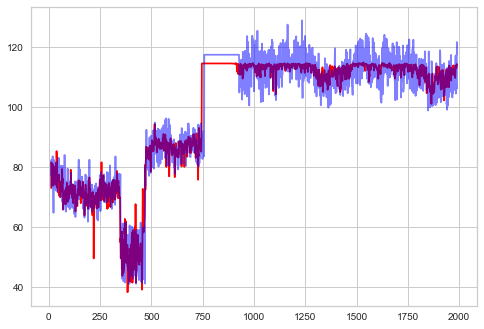

```python
x_ordered = x[['target','input_1','input_2','input_3','input_4','input_5','input_6','target_t-1','input_1_t-1','input_2_t-1','input_3_t-1','input_4_t-1','input_5_t-1','input_6_t-1','target_t-2','input_1_t-2','input_2_t-2','input_3_t-2','input_4_t-2','input_5_t-2','input_6_t-2','target_t-3','input_1_t-3','input_2_t-3','input_3_t-3','input_4_t-3','input_5_t-3','input_6_t-3','target_t-4','input_1_t-4','input_2_t-4','input_3_t-4','input_4_t-4','input_5_t-4','input_6_t-4','target_t-5','input_1_t-5','input_2_t-5','input_3_t-5','input_4_t-5','input_5_t-5','input_6_t-5','target_t-6','input_1_t-6','input_2_t-6','input_3_t-6','input_4_t-6','input_5_t-6','input_6_t-6']]

x_sc=scaler.transform(x_ordered)

x_sc = x_sc.reshape(x_sc.shape[0], 7, 7)


x_lstm = x_sc


y_pred_all = model3.predict(x_lstm)
p1 = plt.plot(pd.DataFrame({'y': y, 'y_pred': y_pred_all[:,0]})['y_pred'], color='red',label='Prediction')
p2 = plt.plot(pd.DataFrame({'y': y, 'y_pred': y_pred_all[:,0]})['y'], color='blue', label='Observed', alpha = 0.5)
```

```python
model3.fit(x_lstm, y, epochs=200, verbose=0)
```

```
<tensorflow.python.keras.callbacks.History at 0x23fbb9f8438>
```

```python
model_json = model3.to_json()
with open("../models/lstm_model.json", "w") as json_file:
    json_file.write(model_json)
model3.save_weights("../models/lstm_model.h5")
```